# Human Resources Analytics

Bauyrjan

10/13/2017

# Introduction

Motivation: Why are our best and most experienced employees leaving the company prematurely?

We will use the following dataset from Kaggle database and will try to predict which valuable employees will leave the company next.

This dataset is simulated dataset and is downloaded from Kaggle website.

Fields in the dataset include:

- Satisfaction Level
- Last evaluation
- Number of projects
- Average monthly hours
- Time spent at the company
- Whether they have had a work accident
- Whether they have had a promotion in the last 5 years
- Departments
- Salary
- Whether the employee has left (“0” denotes stayed employees, “1” denotes employees who left)

# Load data and peform Exploratory Data Analysis

```r
hr<-read.csv("HR_comma_sep.csv", header = T)
hr<-hr %>% mutate(EmployeeLabel = rownames(hr))
```

1. Let’s see how data looks like and how it structures

```
## 'data.frame':    14999 obs. of  11 variables:
##  $ satisfaction_level   : num  0.38 0.8 0.11 0.72 0.37 0.41 0.1 0.92 0.89 0.42 ...
##  $ last_evaluation      : num  0.53 0.86 0.88 0.87 0.52 0.5 0.77 0.85 1 0.53 ...
##  $ number_project       : int  2 5 7 5 2 2 6 5 5 2 ...
##  $ average_montly_hours : int  157 262 272 223 159 153 247 259 224 142 ...
##  $ time_spend_company   : int  3 6 4 5 3 3 4 5 5 3 ...
##  $ Work_accident        : int  0 0 0 0 0 0 0 0 0 0 ...
##  $ left                 : int  1 1 1 1 1 1 1 1 1 1 ...
##  $ promotion_last_5years: int  0 0 0 0 0 0 0 0 0 0 ...
##  $ sales                : Factor w/ 10 levels "accounting","hr",..: 8 8 8 8 8 8 8 8 8 8 ...
##  $ salary               : Factor w/ 3 levels "high","low","medium": 2 3 3 2 2 2 2 2 2 2 ...
##  $ EmployeeLabel        : chr  "1" "2" "3" "4" ...
```

2. Let’s get a sense of number of people who left their jobs

```r
table(hr$left)
```

```
##
##     0     1
## 11428  3571
```

3. Let’s see the job types and number of employees in each type of job

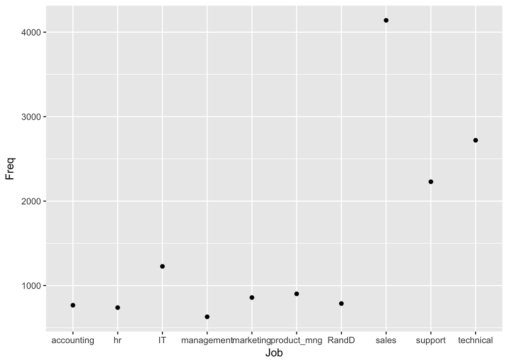

4. Let’s see relationship between satisfaction level, jobs, and the people who left their jobs

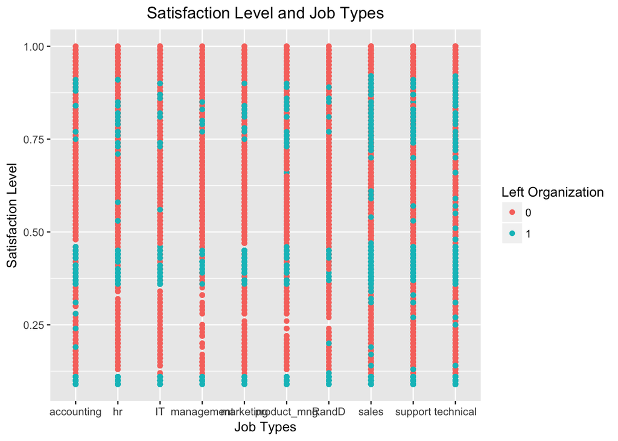

```r
ggplot(data = hr, aes(x=sales, y=satisfaction_level, color=as.factor(left)))+geom_point()+ggtitle("Satisfaction Level and Job Types")+labs(y="Satisfaction Level", x="Job Types", colour="Left Organization")+theme(plot.title = element_text(hjust = 0.5))
```

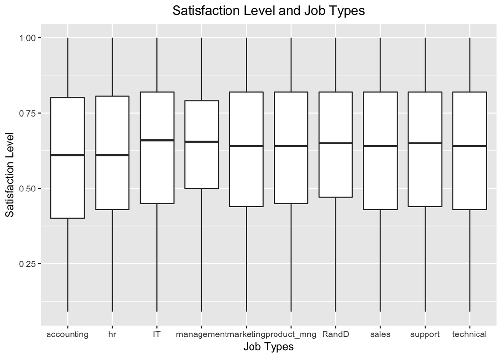

```r
ggplot(data = hr, aes(x=sales, y=satisfaction_level))+geom_boxplot()+ggtitle("Satisfaction Level and Job Types")+labs(y="Satisfaction Level", x="Job Types")+theme(plot.title = element_text(hjust = 0.5))
```

6. Let’s see relationship between satisfaction level, salary, and the people who left their jobs

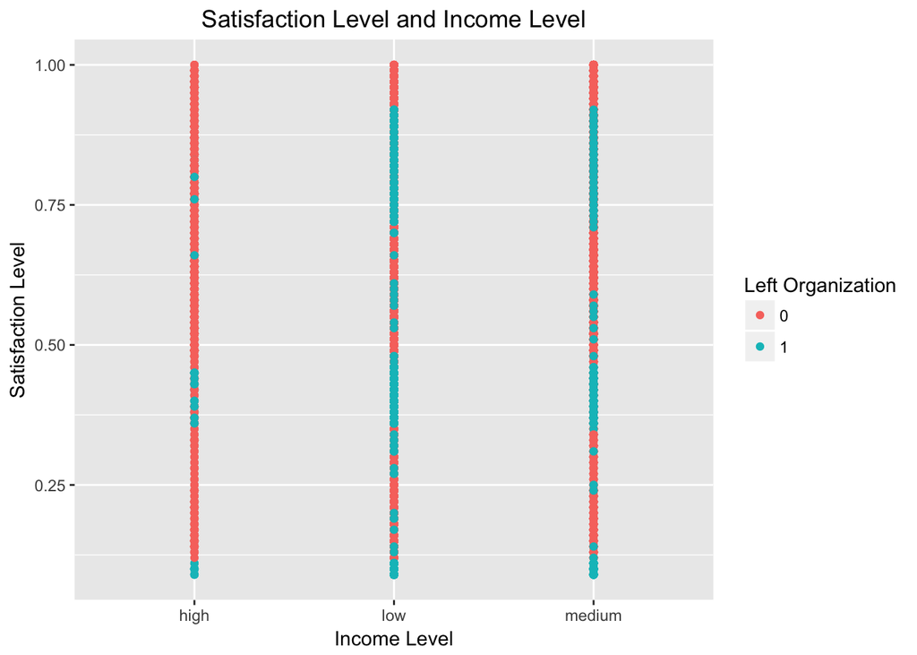

```r
ggplot(data = hr, aes(x=salary, y=satisfaction_level, color=as.factor(left)))+geom_point()+ggtitle("Satisfaction Level and Income Level")+labs(y="Satisfaction Level", x="Income Level", colour="Left Organization")+theme(plot.title = element_text(hjust = 0.5))
```

7. Let’s see relationship between satisfaction level, last evaluation and the people who left their jobs

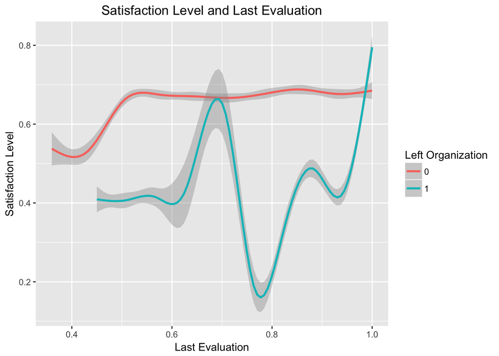

```r
ggplot(data = hr, aes(x=last_evaluation, y=satisfaction_level, color=as.factor(left)))+geom_smooth()+ggtitle("Satisfaction Level and Last Evaluation")+labs(y="Satisfaction Level", x="Last Evaluation", colour="Left Organization")+theme(plot.title = element_text(hjust = 0.5))
```

8. Let’s see relationship between satisfaction level, number of projects and the people who left their jobs

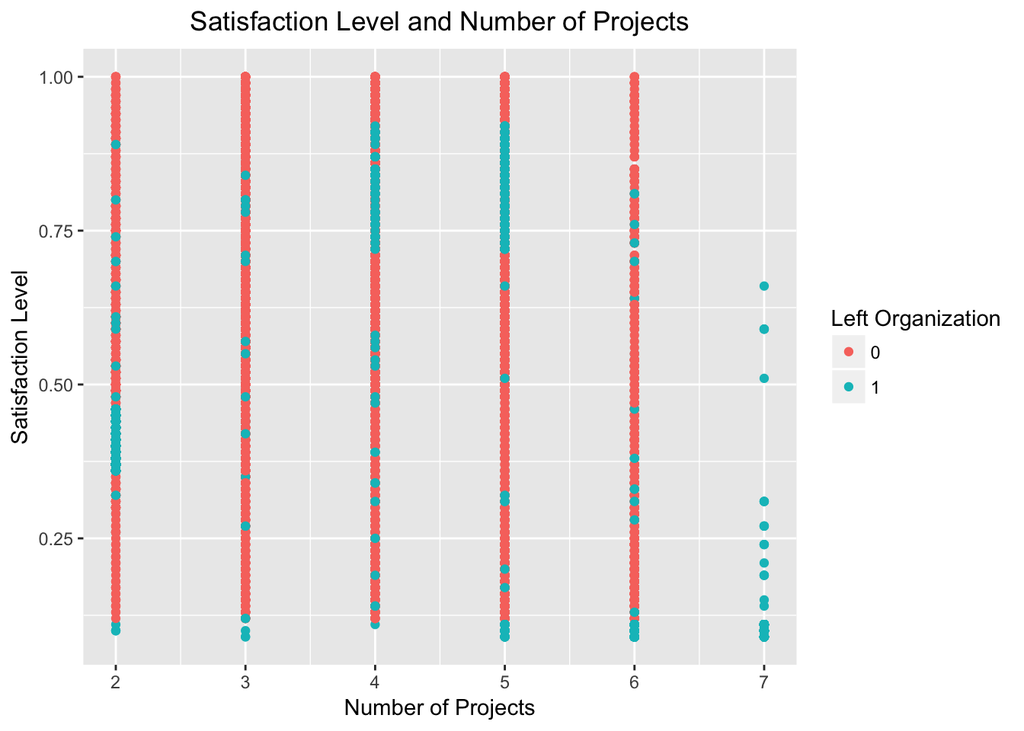

```r
ggplot(data = hr, aes(x=number_project, y=satisfaction_level, color=as.factor(left)))+geom_point()+ggtitle("Satisfaction Level and Number of Projects")+labs(y="Satisfaction Level", x="Number of Projects", colour="Left Organization")+theme(plot.title = element_text(hjust = 0.5))
```

9. Let’s see relationship between average monthly hours, number of projects and the people who left their jobs

[figure not shown]

```r
ggplot(data = hr, aes(x=average_montly_hours, y=number_project, color=as.factor(left)))+geom_smooth()+ggtitle("Average Monthly Hours and Number of Projects")+labs(y="Average Monthly Hours", x="Number of Projects", colour="Left Organization")+theme(plot.title = element_text(hjust = 0.5))
```

10. Let’s see relationship between number of projects, last evaluation and the people who left their jobs

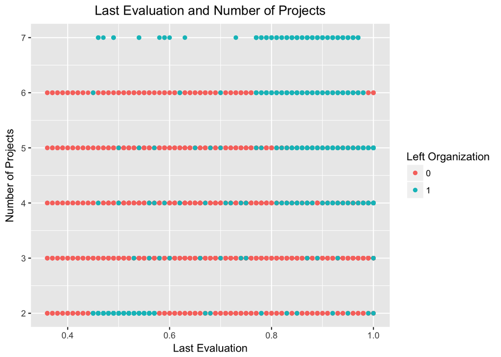

```r
ggplot(data = hr, aes(x=last_evaluation, y=number_project, color=as.factor(left)))+geom_point()+ggtitle("Last Evaluation and Number of Projects")+labs(y="Number of Projects", x="Last Evaluation", colour="Left Organization")+theme(plot.title = element_text(hjust = 0.5))
```

# Data splitting

```r
set.seed(123)
inTrain<-createDataPartition(y=hr$left, p=0.75, list = FALSE)
train<-hr[inTrain,]
test<-hr[-inTrain,]
```

# Feature Selection

Let’s conduct features analysis with building correlation matrix between variables

```r
# calculate correlation matrix
correlationMatrix <- cor(hr[,1:6])
# summarize the correlation matrix
print(correlationMatrix)
```

```
##                      satisfaction_level last_evaluation number_project
## satisfaction_level           1.00000000     0.105021214   -0.142969586
## last_evaluation              0.10502121     1.000000000    0.349332589
## number_project              -0.14296959     0.349332589    1.000000000
## average_montly_hours        -0.02004811     0.339741800    0.417210634
## time_spend_company          -0.10086607     0.131590722    0.196785891
## Work_accident                0.05869724    -0.007104289   -0.004740548
##                      average_montly_hours time_spend_company Work_accident
## satisfaction_level            -0.02004811       -0.100866073   0.058697241
## last_evaluation                0.33974180        0.131590722  -0.007104289
## number_project                 0.41721063        0.196785891  -0.004740548
## average_montly_hours           1.00000000        0.127754910  -0.010142888
## time_spend_company             0.12775491        1.000000000   0.002120418
## Work_accident                 -0.01014289        0.002120418   1.000000000
```

```r
# find attributes that are highly correlated (ideally >0.75)
highlyCorrelated <- findCorrelation(correlationMatrix, cutoff=0.5)
# print indexes of highly correlated attributes
print(highlyCorrelated)
```

```
## integer(0)
```

Let’s analyze importance of the variables

```r
# train a model
model <- train(as.factor(left)~.-EmployeeLabel, data=train, method="rpart")
# estimate variable importance
importance <- varImp(model, scale=FALSE)
# summarize importance
print(importance)
```

```
## rpart variable importance
##
##                       Overall
## satisfaction_level     2155.1
## number_project         1509.2
## average_montly_hours    846.2
## time_spend_company      692.2
## last_evaluation         574.6
## salarymedium              0.0
## salesIT                   0.0
## saleshr                   0.0
## salesproduct_mng          0.0
## salarylow                 0.0
## salesRandD                0.0
## salessales                0.0
## salestechnical            0.0
## promotion_last_5years     0.0
## salesmarketing            0.0
## salesmanagement           0.0
## Work_accident             0.0
## salessupport              0.0
```

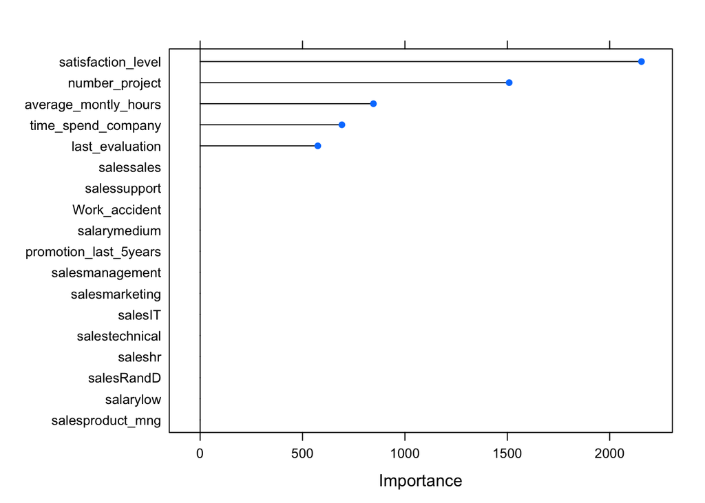

```r
# plot importance
plot(importance)
```

Select feature

```r
control <- rfeControl(functions=rfFuncs, method="cv", number=3)
# run the RFE algorithm
results <- rfe(train[,1:6], as.factor(train[,7]), sizes=c(1:8), rfeControl=control)
# summarize the results
print(results)
```

```
##
## Recursive feature selection
##
## Outer resampling method: Cross-Validated (3 fold)
##
## Resampling performance over subset size:
##
##  Variables Accuracy  Kappa AccuracySD  KappaSD Selected
##          1   0.8922 0.6823  0.0040118 0.011440
##          2   0.9105 0.7284  0.0015163 0.004225
##          3   0.9568 0.8783  0.0195814 0.057010
##          4   0.9848 0.9577  0.0010667 0.002974
##          5   0.9885 0.9680  0.0007055 0.002049        *
##          6   0.9868 0.9632  0.0013154 0.003786
##
## The top 5 variables (out of 5):
##    satisfaction_level, number_project, time_spend_company, average_montly_hours, last_evaluation
```

```r
# list the chosen features
predictors(results)
```

```
## [1] "satisfaction_level"   "number_project"       "time_spend_company"
## [4] "average_montly_hours" "last_evaluation"
```

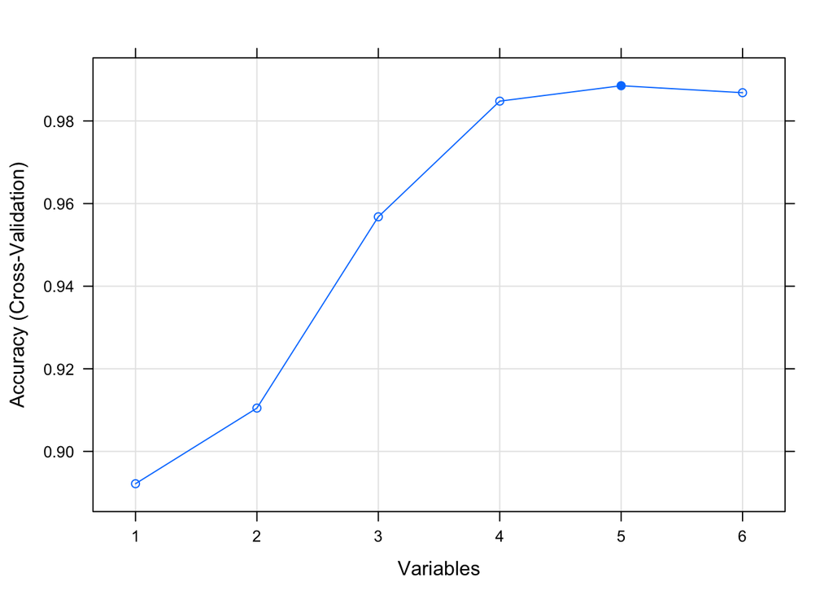

```r
# plot the results
plot(results, type=c("g", "o"))
```

# Train models

1.Gradient Boosting Model

```r
set.seed(234)
fitControl<-trainControl(method = "repeatedcv", number = 10, repeats = 3)
fit_1_all<-train(as.factor(left)~., data = train[,!colnames(train) %in% c("EmployeeLabel")], method="gbm", trControl=fitControl, verbose=FALSE)
fit_1_select<-train(as.factor(left)~satisfaction_level+number_project+time_spend_company+average_montly_hours+last_evaluation, data = train[,!colnames(train) %in% c("EmployeeLabel")], method="gbm", trControl=fitControl, verbose=FALSE)
```

2. Logistics Regression Model

```r
fit_2_all<-train(as.factor(left)~., data=train[,!colnames(train) %in% c("EmployeeLabel")], method="glm", family="binomial")
fit_2_select<-train(as.factor(left)~satisfaction_level+number_project+time_spend_company+average_montly_hours+last_evaluation, data=train[,!colnames(train) %in% c("EmployeeLabel")], method="glm", family="binomial")
```

3. Decision Tree Model

```r
fitControl<-trainControl(method = "repeatedcv", number = 10, repeats = 3)
fit_3<-train(as.factor(left)~satisfaction_level+number_project+time_spend_company+average_montly_hours+last_evaluation, data = train[,!colnames(train) %in% c("EmployeeLabel")], method = "rpart", parms = list(split = "information"), trControl=fitControl, tuneLength = 10)
```

# Apply models to the test data set

```r
# Model 1
predict_1_all<-predict(fit_1_all, newdata=test)
# Model 2
predict_1_select<-predict(fit_1_select, newdata=test)
# Model 3
predict_2_all<-predict(fit_2_all, newdata=test)
# Model 4
predict_2_select<-predict(fit_2_select, newdata=test)
# Model 5
predict_3<-predict(fit_3, newdata=test)
```

# Evaluate predicted results

1. Gradient Boosting Model

```r
# Compare model that accounts for all variables with the model that accounts for only the most important 5 variables
confusionMatrix(predict_1_all, test$left)
```

```
## Confusion Matrix and Statistics
##
##           Reference
## Prediction    0    1
##          0 2825   63
##          1   31  830
##
##                Accuracy : 0.9749
##                  95% CI : (0.9694, 0.9797)
##     No Information Rate : 0.7618
##     P-Value [Acc > NIR] : < 2.2e-16
##
##                   Kappa : 0.9301
##  Mcnemar's Test P-Value : 0.001387
##
##             Sensitivity : 0.9891
##             Specificity : 0.9295
##          Pos Pred Value : 0.9782
##          Neg Pred Value : 0.9640
##              Prevalence : 0.7618
##          Detection Rate : 0.7535
##    Detection Prevalence : 0.7703
##       Balanced Accuracy : 0.9593
##
##        'Positive' Class : 0
##
```

```r
confusionMatrix(predict_1_select, test$left)
```

```
## Confusion Matrix and Statistics
##
##           Reference
## Prediction    0    1
##          0 2824   58
##          1   32  835
##
##                Accuracy : 0.976
##                  95% CI : (0.9706, 0.9807)
##     No Information Rate : 0.7618
##     P-Value [Acc > NIR] : < 2.2e-16
##
##                   Kappa : 0.9332
##  Mcnemar's Test P-Value : 0.008408
##
##             Sensitivity : 0.9888
##             Specificity : 0.9351
##          Pos Pred Value : 0.9799
##          Neg Pred Value : 0.9631
##              Prevalence : 0.7618
##          Detection Rate : 0.7533
##    Detection Prevalence : 0.7687
##       Balanced Accuracy : 0.9619
##
##        'Positive' Class : 0
##
```

2. Logistics Regression Model

```r
# Compare model that accounts for all variables with the model that accounts for only the most important 5 variables
confusionMatrix(predict_2_all, test$left)
```

```
## Confusion Matrix and Statistics
##
##           Reference
## Prediction    0    1
##          0 2665  574
##          1  191  319
##
##                Accuracy : 0.7959
##                  95% CI : (0.7827, 0.8087)
##     No Information Rate : 0.7618
##     P-Value [Acc > NIR] : 3.328e-07
##
##                   Kappa : 0.3405
##  Mcnemar's Test P-Value : < 2.2e-16
##
##             Sensitivity : 0.9331
##             Specificity : 0.3572
##          Pos Pred Value : 0.8228
##          Neg Pred Value : 0.6255
##              Prevalence : 0.7618
##          Detection Rate : 0.7109
##    Detection Prevalence : 0.8640
##       Balanced Accuracy : 0.6452
##
##        'Positive' Class : 0
##
```

```r
confusionMatrix(predict_2_select, test$left)
```

```
## Confusion Matrix and Statistics
##
##           Reference
## Prediction    0    1
##          0 2648  656
##          1  208  237
##
##                Accuracy : 0.7695
##                  95% CI : (0.7557, 0.7829)
##     No Information Rate : 0.7618
##     P-Value [Acc > NIR] : 0.1371
##
##                   Kappa : 0.2327
##  Mcnemar's Test P-Value : <2e-16
##
##             Sensitivity : 0.9272
##             Specificity : 0.2654
##          Pos Pred Value : 0.8015
##          Neg Pred Value : 0.5326
##              Prevalence : 0.7618
##          Detection Rate : 0.7063
##    Detection Prevalence : 0.8813
##       Balanced Accuracy : 0.5963
##
##        'Positive' Class : 0
##
```

3. Decision Tree Model

```r
confusionMatrix(predict_3, test$left)
```

```
## Confusion Matrix and Statistics
##
##           Reference
## Prediction    0    1
##          0 2831   69
##          1   25  824
##
##                Accuracy : 0.9749
##                  95% CI : (0.9694, 0.9797)
##     No Information Rate : 0.7618
##     P-Value [Acc > NIR] : < 2.2e-16
##
##                   Kappa : 0.9297
##  Mcnemar's Test P-Value : 9.202e-06
##
##             Sensitivity : 0.9912
##             Specificity : 0.9227
##          Pos Pred Value : 0.9762
##          Neg Pred Value : 0.9706
##              Prevalence : 0.7618
##          Detection Rate : 0.7551
##    Detection Prevalence : 0.7735
##       Balanced Accuracy : 0.9570
##
##        'Positive' Class : 0
##
```

# Apply the best model and see first 10 employees who are predicted to leave the company

```r
test_new<-test %>% mutate(predicted = predict_1_select)
predicted_left<-filter(test_new, predicted=="1")
```

The list of Employee Labels of the first 10 employees who are predicted to leave the company

```r
head(predicted_left$EmployeeLabel, 10)
```

```
##  [1] "2"  "3"  "9"  "11" "12" "20" "28" "31" "36" "39"
```

# APPENDIX - Deep dive analysis

1. Let’s deep dive into the point #7 from the Exploratory Data Analysis section

1.1.We will look closer to situation where people left their jobs while they have satisfaction level over 0.6 and last evaluation between 0.68 and 0.73.

1.1.1 Quick glance at table summary of variables

```r
table(left$Work_accident)
```

```
##
## 0
## 8
```

```r
table(left$sales)
```

```
##
##  accounting          hr          IT  management   marketing product_mng
##           0           1           3           0           2           0
##       RandD       sales     support   technical
##           0           0           0           2
```

```r
table(left$promotion_last_5years)
```

```
##
## 0
## 8
```

Above tables show that these people were not promoted in last 5 years, they don’t have any work accidents, and we can also see the job types of these people.

1.1.2 Plot number of projects vs the job type

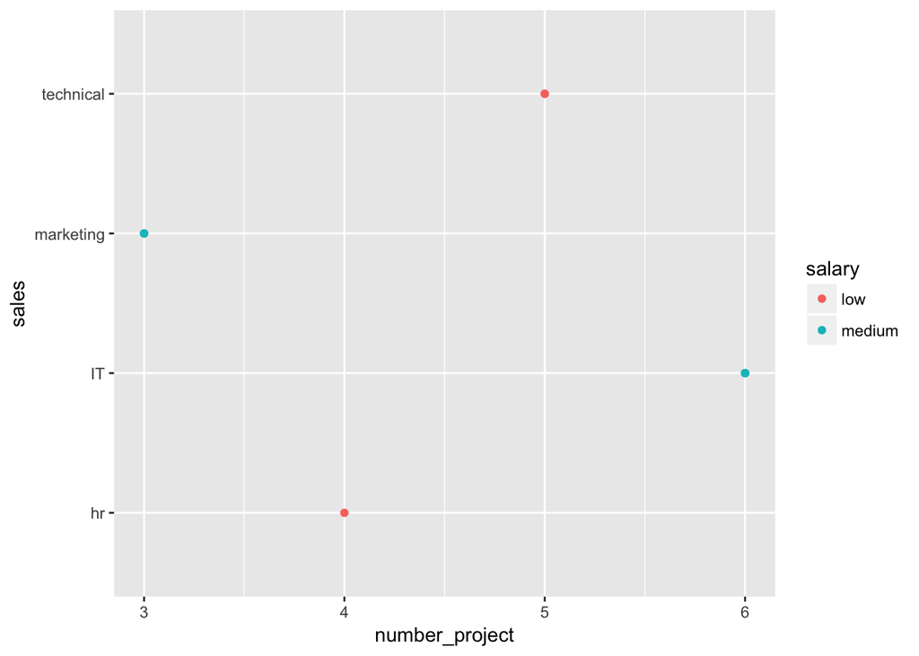

```r
ggplot(data = left, aes(x=number_project, y=sales, color=salary))+geom_point()
```

1.1.3 Histogram of Average Monthly Hours

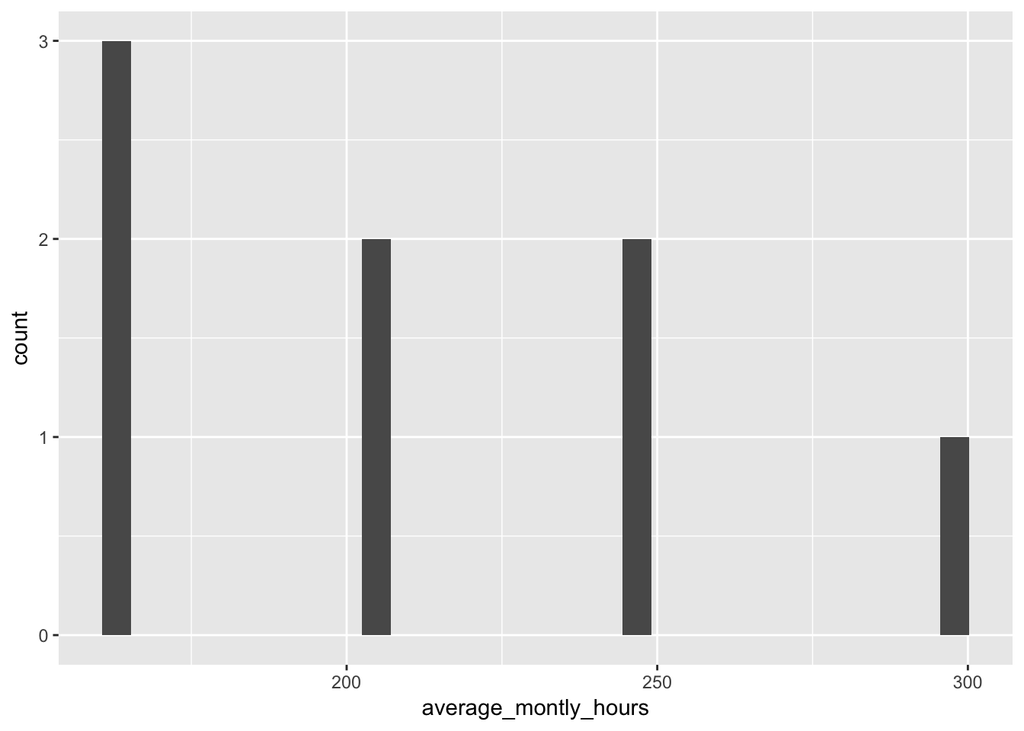

```r
ggplot(left, aes(x = average_montly_hours))+geom_histogram()
```

1.1.4 Histogram of Time Spent at the Company

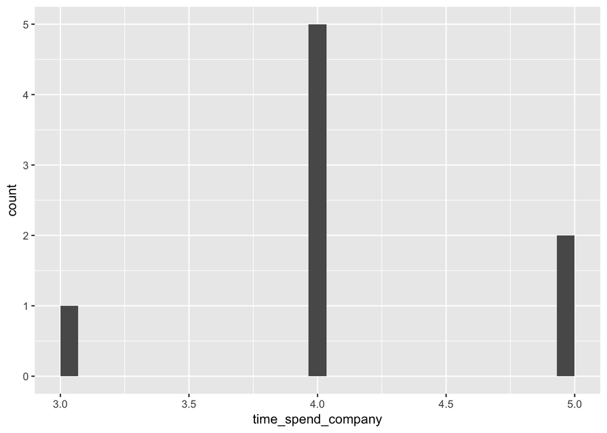

```r
ggplot(left, aes(x = time_spend_company))+geom_histogram()
```

1.2 We will look closer into situation where people left their jobs while they have satisfaction level over 0.6 and last evaluation greater than 0.98

1.2.1 Quick glance at summary of variables

```r
table(left$Work_accident)
```

```
##
##   0   1
## 204  12
```

```r
table(left$sales)
```

```
##
##  accounting          hr          IT  management   marketing product_mng
##          16          10          13           5           5          13
##       RandD       sales     support   technical
##           9          69          24          52
```

```r
table(left$promotion_last_5years)
```

```
##
##   0   1
## 215   1
```

1.2.2 Plot number of projects vs the job type

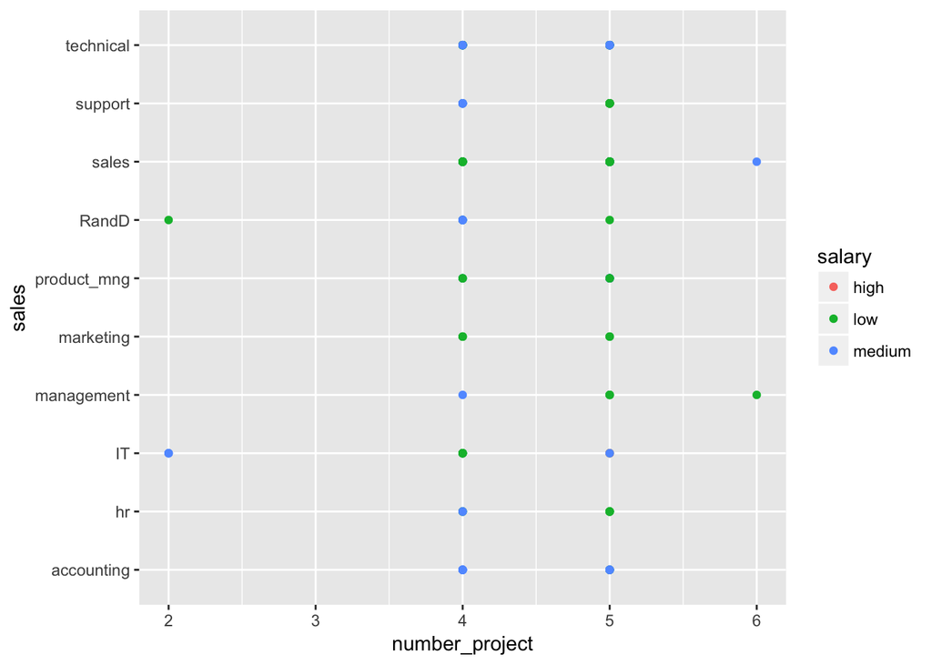

```r
ggplot(data = left, aes(x=number_project, y=sales, color=salary))+geom_point()
```

1.2.3 Histogram of Average Monthly Hours

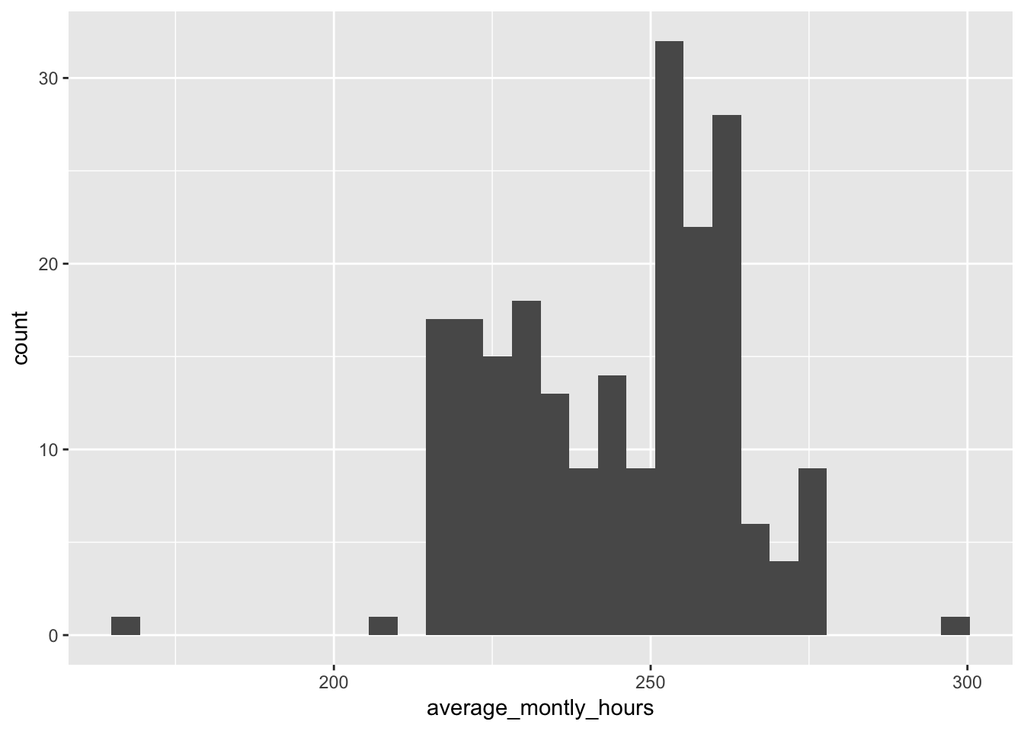

```r
ggplot(left, aes(x = average_montly_hours))+geom_histogram()
```

1.2.4 Histogram of Time Spent at the Company

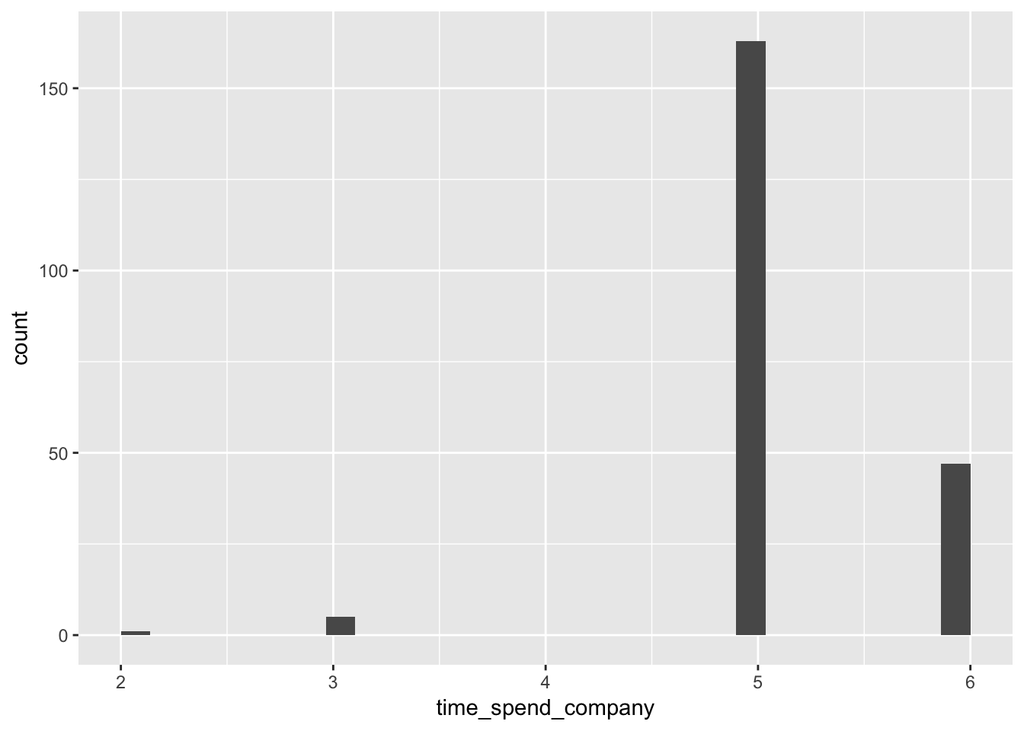

```r
ggplot(left, aes(x = time_spend_company))+geom_histogram()
```

1.3 We will look closer into situation where people did NOT leave their jobs while they have satisfaction level between 0.5 and 0.6 with last evaluation between 0.4 and 0.5

1.3.1 Quick glance at summary of variables

```r
table(left$Work_accident)
```

```
##
##  0  1
## 95 26
```

```r
table(left$sales)
```

```
##
##  accounting          hr          IT  management   marketing product_mng
##           4           5          10           7           3          12
##       RandD       sales     support   technical
##           6          29          19          26
```

```r
table(left$promotion_last_5years)
```

```
##
##   0   1
## 118   3
```

1.3.2 Plot number of projects vs the job type

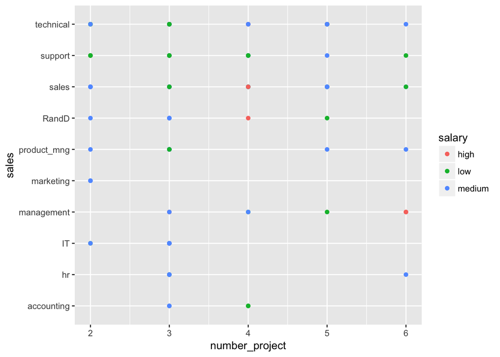

```r
ggplot(data = left, aes(x=number_project, y=sales, color=salary))+geom_point()
```

1.3.3 Histogram of Average Monthly Hours

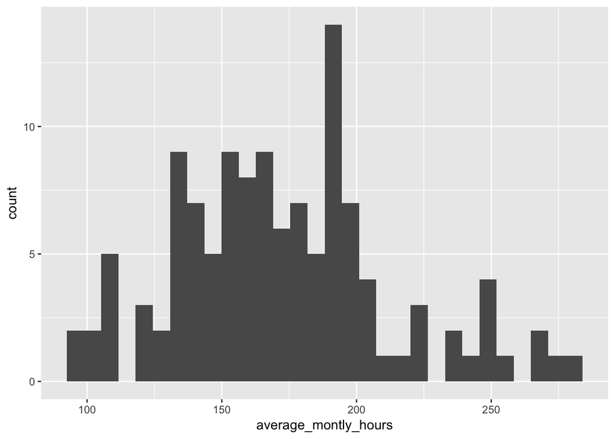

```r
ggplot(left, aes(x = average_montly_hours))+geom_histogram()
```

1.3.4 Histogram of Time Spent at the Company

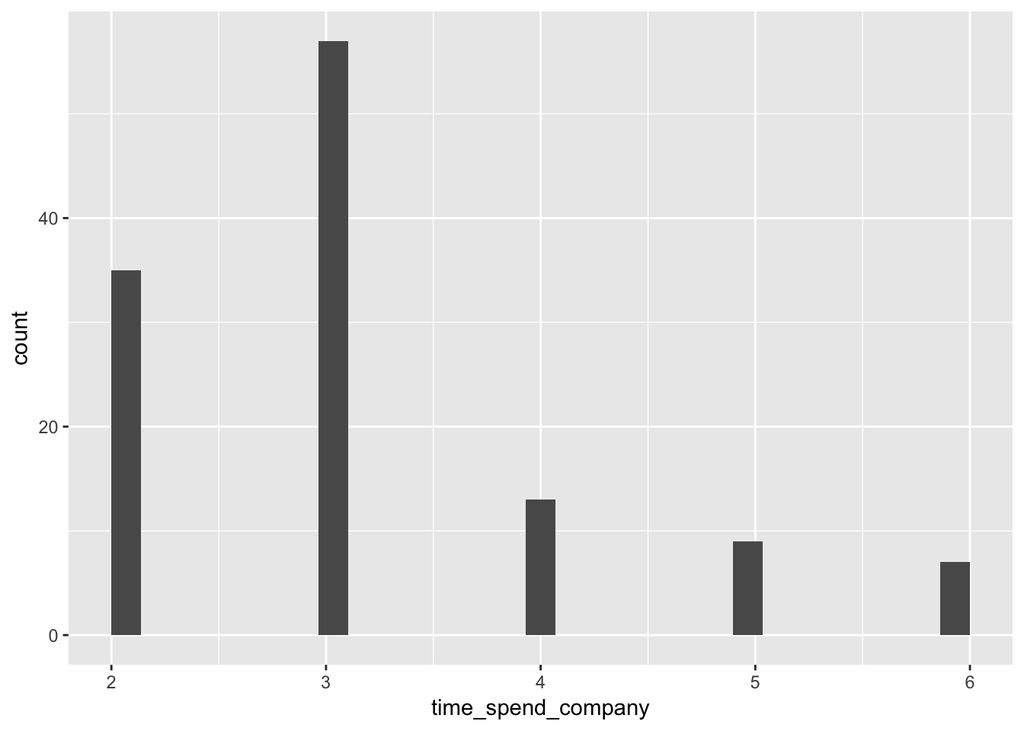

```r
ggplot(left, aes(x = time_spend_company))+geom_histogram()
```

2. Let’s deep dive into the point #8 from the Exploratory Data Analysis section

2.1 We will look closer to situation where people left their jobs while they have satisfaction level over 0.75 and worked on 4 and 5 projects.

2.1.1 Quick glance at summary of variables

```r
table(left$Work_accident)
```

```
##
##   0   1
## 690  40
```

```r
table(left$sales)
```

```
##
##  accounting          hr          IT  management   marketing product_mng
##          34          35          44          21          46          51
##       RandD       sales     support   technical
##          27         214         122         136
```

```r
table(left$promotion_last_5years)
```

```
##
##   0   1
## 726   4
```

2.1.2 Histogram of Average Monthly Hours

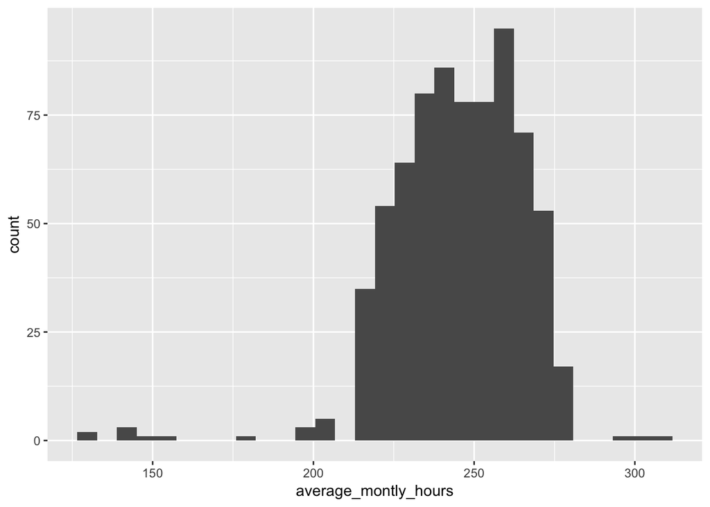

```r
ggplot(left, aes(x = average_montly_hours))+geom_histogram()
```

2.1.3 Histogram of Time Spent at the Company

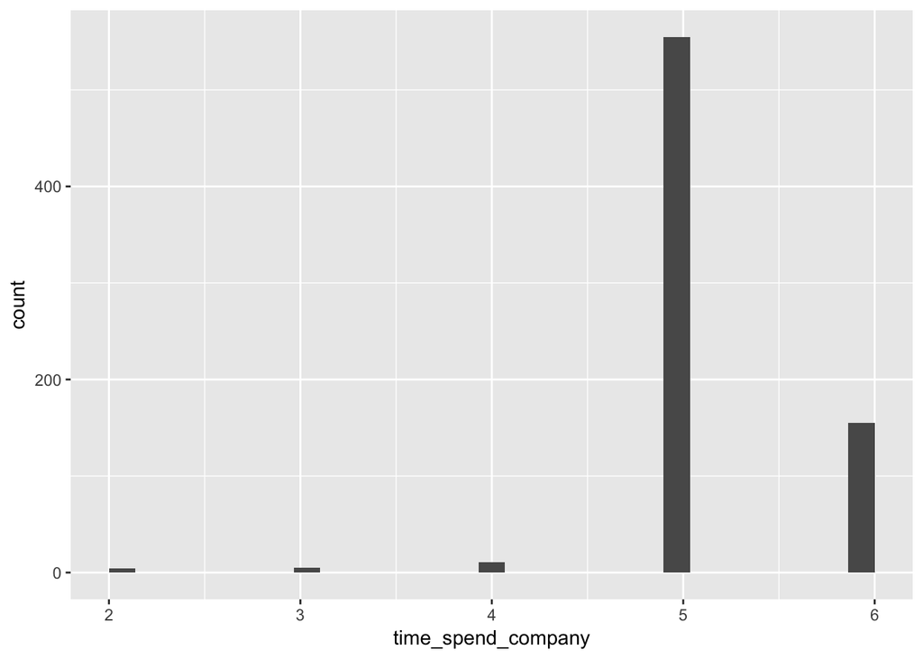

```r
ggplot(left, aes(x = time_spend_company))+geom_histogram()
```

2.2 We will look closer to situation where people left their jobs regardless of their satisfaction level while they worked on 7 projects

2.2.1 Quick glance at summary of variables

```r
table(left$Work_accident)
```

```
##
##   0   1
## 252   4
```

```r
table(left$sales)
```

```
##
##  accounting          hr          IT  management   marketing product_mng
##          15          13          20          13          15          16
##       RandD       sales     support   technical
##          13          67          26          58
```

```r
table(left$promotion_last_5years)
```

```
##
##   0
## 256
```

2.2.2 Histogram of Average Monthly Hours

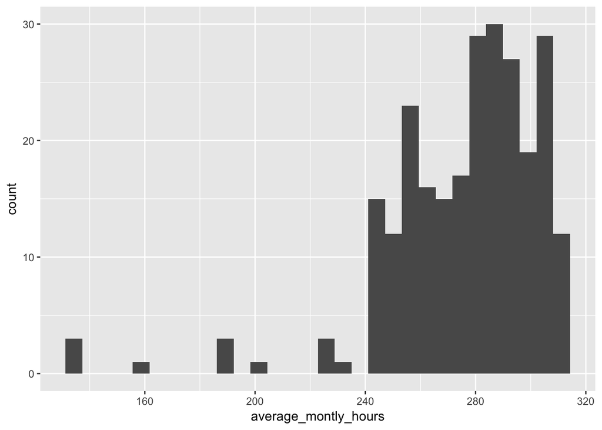

```r
ggplot(left, aes(x = average_montly_hours))+geom_histogram()
```

2.2.3 Histogram of Time Spent at the Company

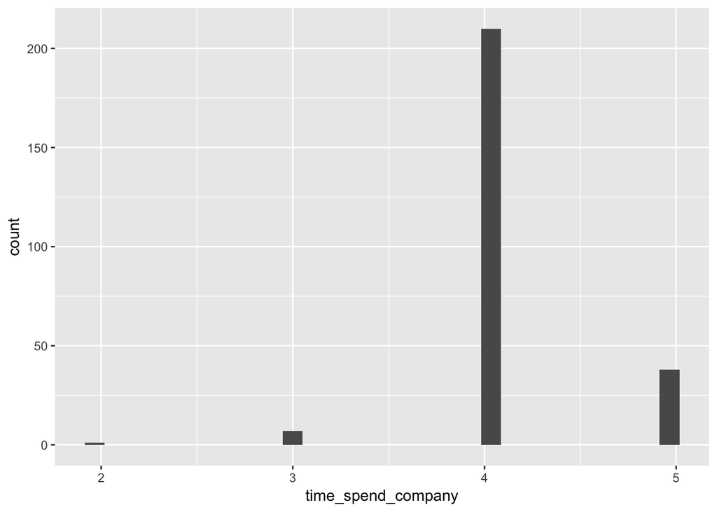

```r
ggplot(left, aes(x = time_spend_company))+geom_histogram()
```

3. Let’s deep dive into the point #6 from the Exploratory Data Analaysis section

3.1 We will look closer to situation where people left their jobs while they had low salary and satisfaction level over 0.65

3.1.1 Quick glance at summary of variables

```r
table(left$Work_accident)
```

```
##
##   0   1
## 563  17
```

```r
table(left$sales)
```

```
##
##  accounting          hr          IT  management   marketing product_mng
##          18          27          47          19          31          40
##       RandD       sales     support   technical
##          18         197          95          88
```

```r
table(left$promotion_last_5years)
```

```
##
##   0   1
## 577   3
```

3.1.2 Histogram of Average Monthly Hours

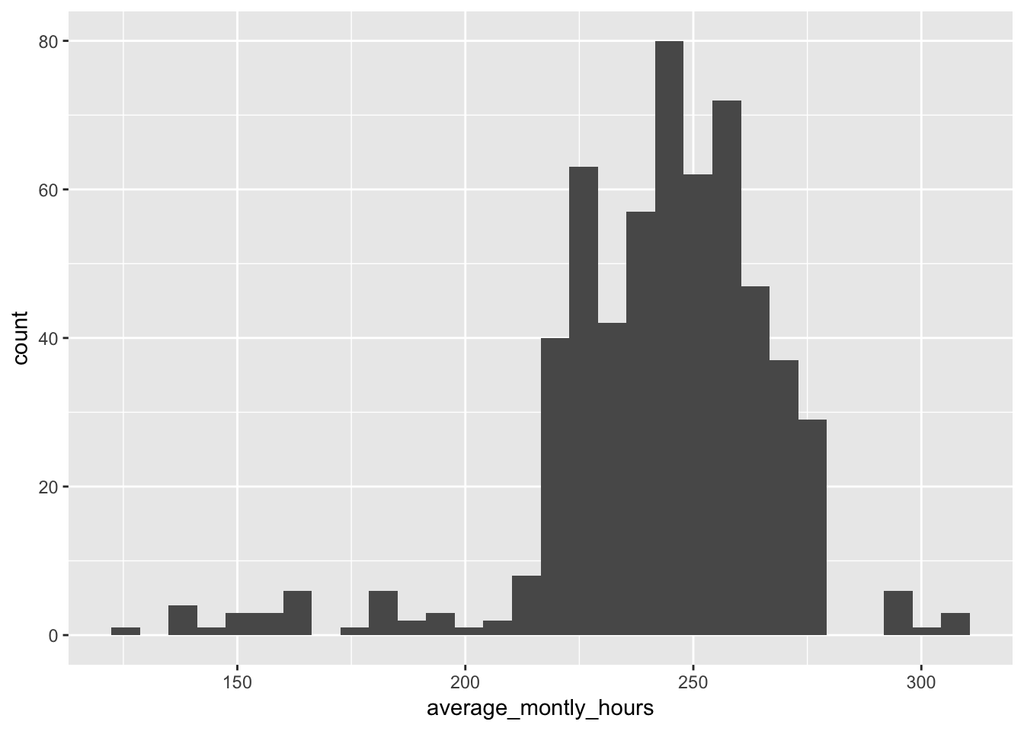

```r
ggplot(left, aes(x = average_montly_hours))+geom_histogram()
```

3.1.3 Histogram of Time Spent at the Company

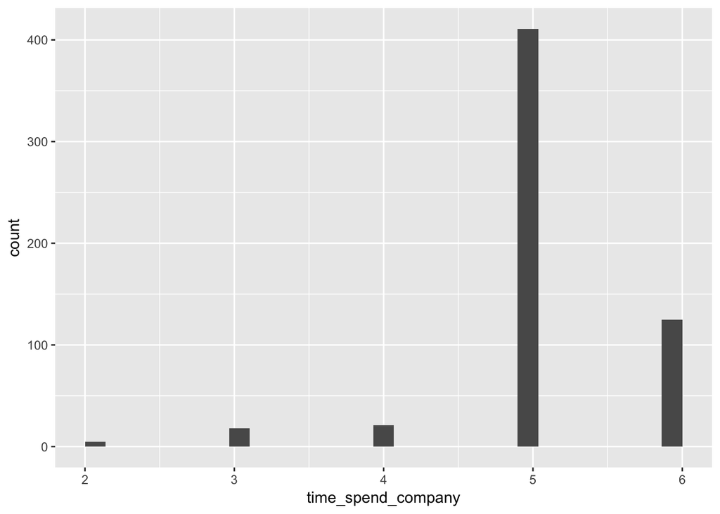

```r
ggplot(left, aes(x = time_spend_company))+geom_histogram()
```

3.1.4 Plot number of projects vs the job type

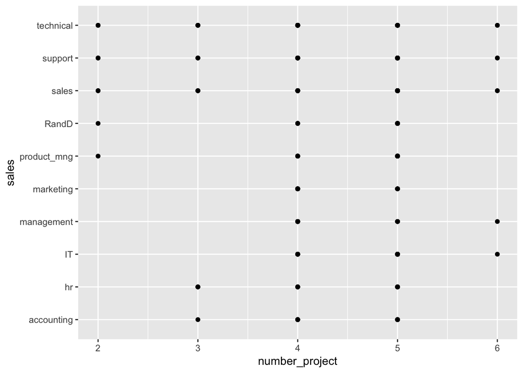

```r
ggplot(data = left, aes(x=number_project, y=sales))+geom_point()
```

3.2 We will look closer to situation where people left their jobs while they had medium salary and satisfaction level over 0.65

3.2.1 Quick glance at summary of variables

```r
table(left$Work_accident)
```

```
##
##   0   1
## 328  30
```

```r
table(left$sales)
```

```
##
##  accounting          hr          IT  management   marketing product_mng
##          23          21          20           6          21          28
##       RandD       sales     support   technical
##          17          66          62          94
```

```r
table(left$promotion_last_5years)
```

```
##
##   0   1
## 357   1
```

3.2.2 Histogram of Average Monthly Hours

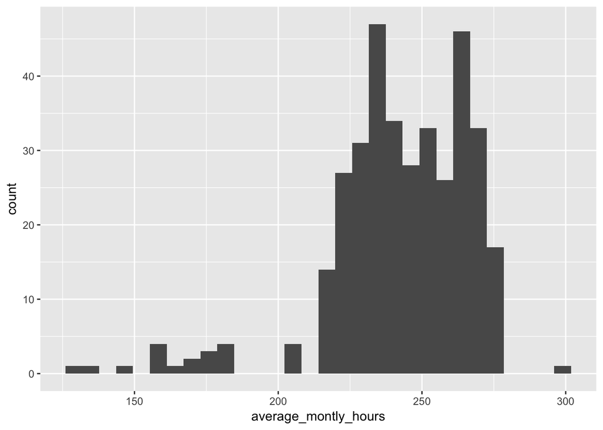

```r
ggplot(left, aes(x = average_montly_hours))+geom_histogram()
```

3.2.3 Histogram of Time Spent at the Company

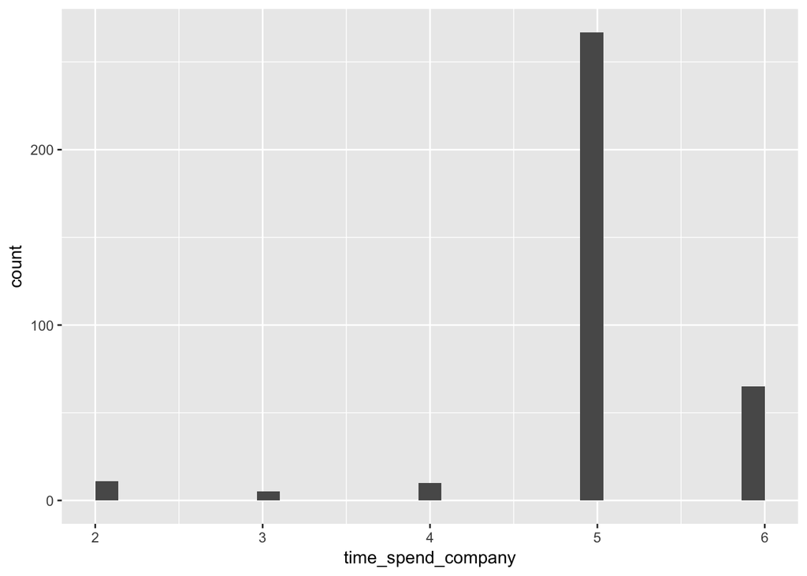

```r
ggplot(left, aes(x = time_spend_company))+geom_histogram()
```

3.2.4 Plot number of projects vs the job type

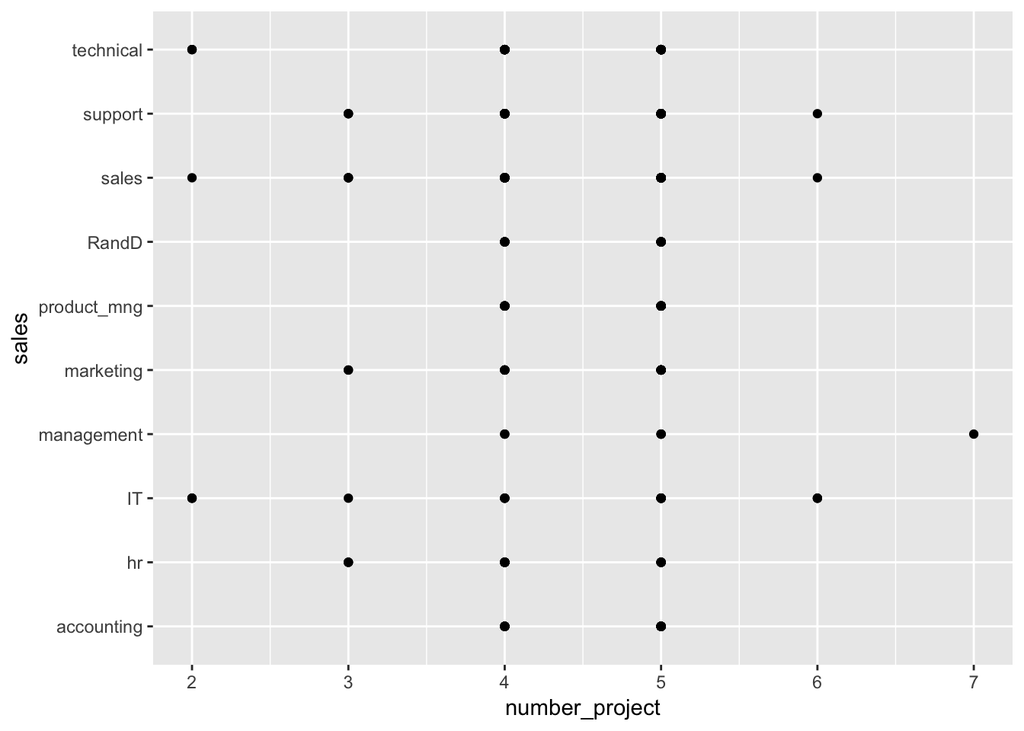

```r
ggplot(data = left, aes(x=number_project, y=sales))+geom_point()
```

3.3 Why do people from Sales, Support, and Technical departments leave their jobs while they satisfaction level over 0.65

3.3.1 Quick glance at summary of variables

```r
table(left$Work_accident)
```

```
##
##   0   1
## 590  28
```

```r
table(left$sales)
```

```
##
##  accounting          hr          IT  management   marketing product_mng
##           0           0           0           0           0           0
##       RandD       sales     support   technical
##           0         268         160         190
```

```r
table(left$promotion_last_5years)
```

```
##
##   0   1
## 617   1
```

3.3.2 Histogram of Average Monthly Hours

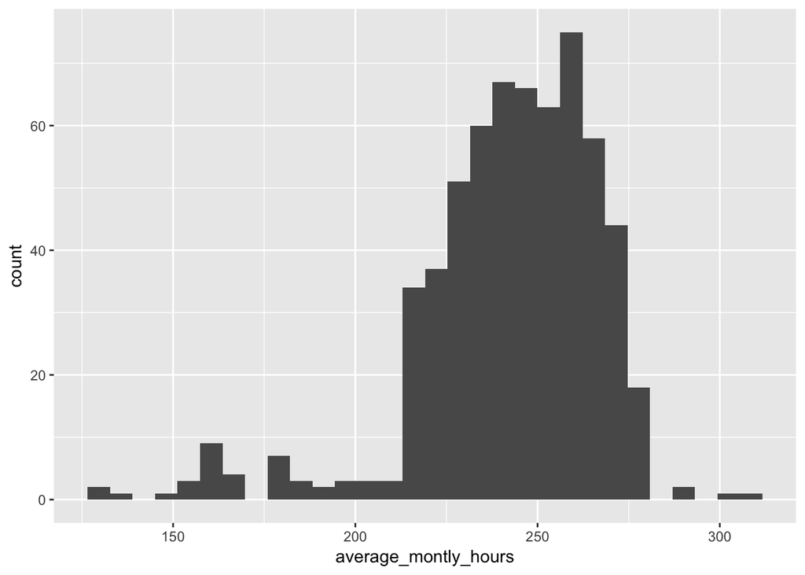

```r
ggplot(left, aes(x = average_montly_hours))+geom_histogram()
```

3.3.3 Histogram of Time Spent at the Company

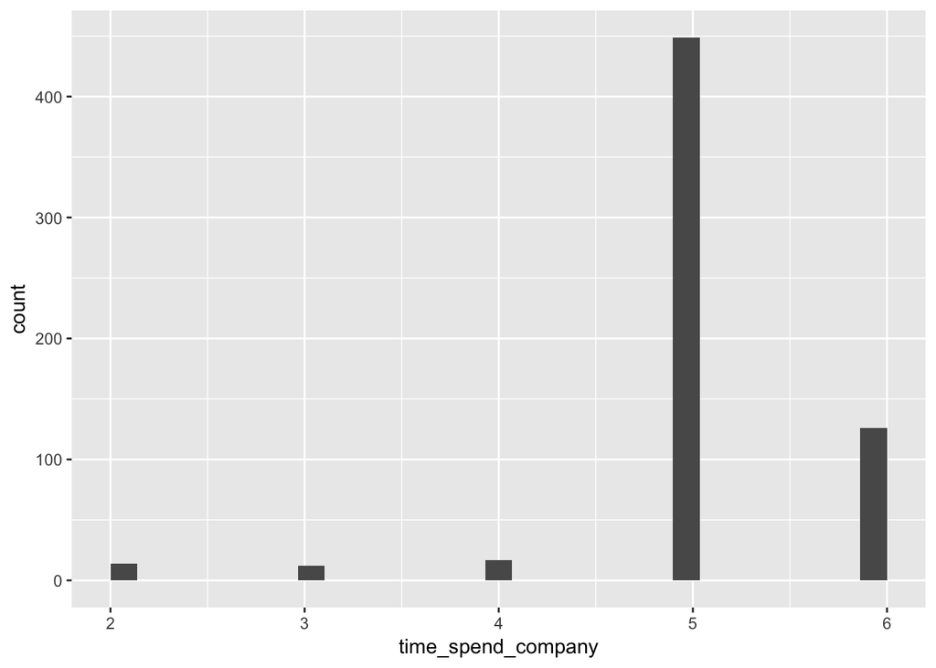

```r
ggplot(left, aes(x = time_spend_company))+geom_histogram()
```

3.3.4 Plot number of projects vs the job type

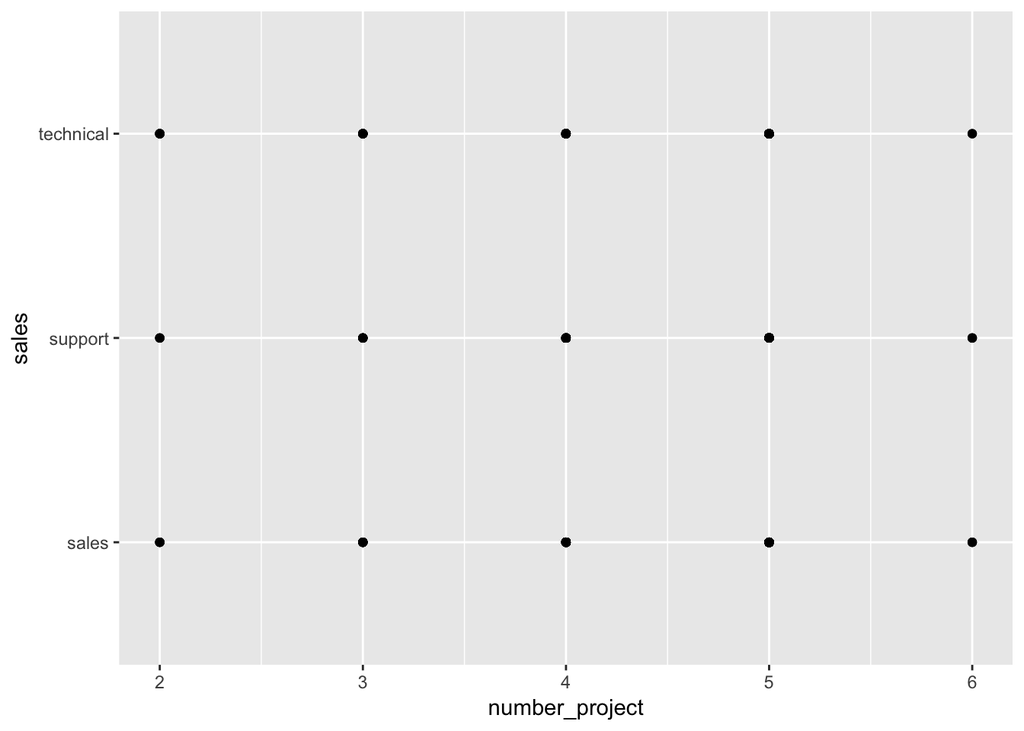

```r
ggplot(data = left, aes(x=number_project, y=sales))+geom_point()
```